# Skylar Wyant - Week 5 Lab

```python
import matplotlib.pyplot as plt
from matplotlib import rc
import seaborn as sns
```

#### Base figure code

```python
f, ax = plt.subplots()
x = [i for i in range(10)]
y = [i**2 for i in x]
ax.plot(x, y)
ax.set_xlabel('x')
ax.set_ylabel('y');
```

#### Plot 1

Change it so that the x axis label is σ and the y axis label is τ. Those are the Greek letters “sigma” and “tau”, respectively.

Take the same plot, and change the x axis label to σ2s.

For the same plot as above, change the plot so that the line is red, “dot-dash”, and 3 times the default line thickness.

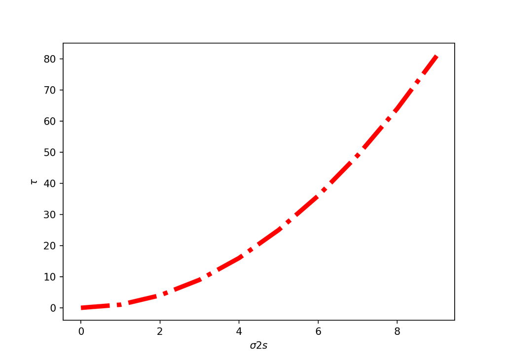

```python
f, ax = plt.subplots()
x = [i for i in range(10)]
y = [i**2 for i in x]
# The default linewidth is 1.5, so multiply that by 3
ax.plot(x, y, color='red', linewidth=3*1.5, linestyle='dashdot')
ax.set_xlabel('$\sigma2s$')
ax.set_ylabel('$\\tau$')
plt.show()
```

#### Plot 2

Take the graph we started with, and assume there’s a variable y = 7. Add a title to the graph that says Γ=7. (That’s the Greek letter “gamma”.) Do it using the variable! Don’t “hard-code” in the value!

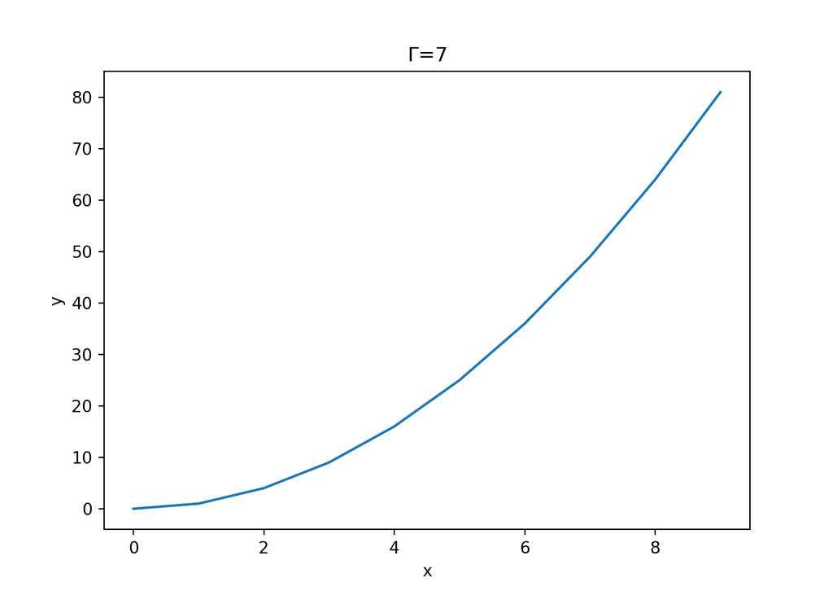

```python
y = 7
title = '$\Gamma$' + '=' + str(y)
f, ax = plt.subplots()
x = [i for i in range(10)]
y = [i**2 for i in x]
ax.plot(x, y)
ax.set_xlabel('x')
ax.set_ylabel('y')
plt.title(title)
plt.show()
```

#### Plot 3

Take the graph we started with, and assume there’s a variable y = 7. Add a text element at coordinates x=0.1, y=0.4 to the graph that says Γ=7.

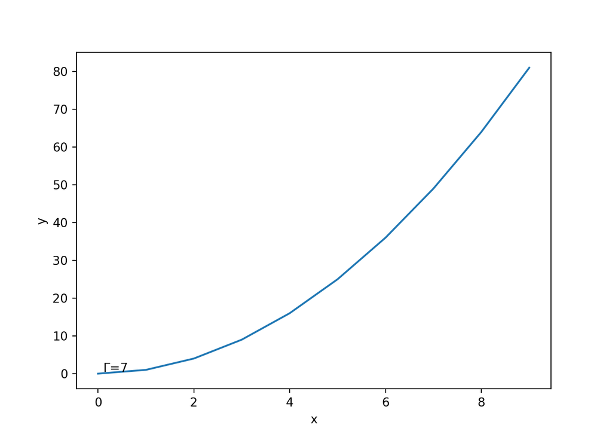

```python
y = 7
textstr = '$\Gamma$' + '=' + str(y)
f, ax = plt.subplots()
x = [i for i in range(10)]
y = [i**2 for i in x]
ax.plot(x, y)
ax.set_xlabel('x')
ax.set_ylabel('y')
ax.text(0.1, 0.4, textstr)
plt.show()
```

#### Saving files

Save one of your graphics in the following formats:

- pdf with 18 point font, 10" by 10" square
- tiff with 18 point font, 10" by 10" square and the x axis font is 1/2 the global font size.
- 72 dpi png with 18 point font, 10" by 10" square
- 300 dpi png with 18 point font, 10" by 10" square

```python
rc('font', size=18)
f, ax = plt.subplots()
x = [i for i in range(10)]
y = [i**2 for i in x]
ax.plot(x, y)
ax.set_xlabel('x')
ax.set_ylabel('y')
ax.text(0.1, 0.4, textstr)
f.set_size_inches(10, 10)
plt.savefig('save1.pdf')
```

```python
rc('font', size=18)
f, ax = plt.subplots()
x = [i for i in range(10)]
y = [i**2 for i in x]
ax.plot(x, y)
ax.set_xlabel('x', fontsize=plt.rcParams['font.size']/2)
ax.set_ylabel('y')
ax.text(0.1, 0.4, textstr)
f.set_size_inches(10, 10)
plt.savefig('save2.tiff')
```

```python
rc('font', size=18)
f, ax = plt.subplots()
x = [i for i in range(10)]
y = [i**2 for i in x]
ax.plot(x, y)
ax.set_xlabel('x')
ax.set_ylabel('y')
ax.text(0.1, 0.4, textstr)
f.set_size_inches(10, 10)
plt.savefig('save3.png', dpi=72)
```

```python
rc('font', size=18)
f, ax = plt.subplots()
x = [i for i in range(10)]
y = [i**2 for i in x]
ax.plot(x, y)
ax.set_xlabel('x')
ax.set_ylabel('y')
ax.text(0.1, 0.4, textstr)
f.set_size_inches(10, 10)
plt.savefig('save4.png', dpi=300)
```

#### Seaborn portion

Repeat the various manipulations above. Where the above instructions refer to lines, change point color/size/shape instead.

#### Base figure

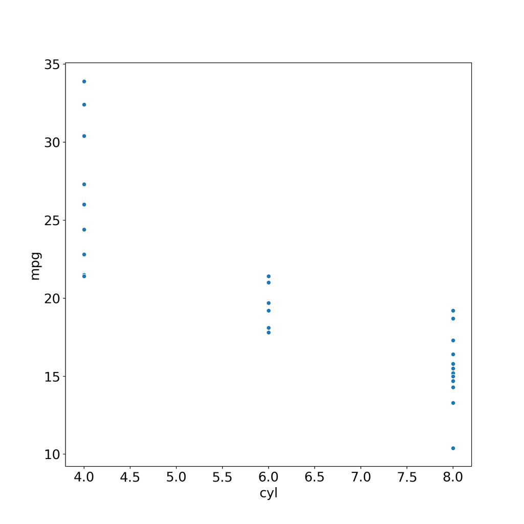

```python
plt.clf()
mtcars = r.mtcars
f = sns.scatterplot(
    data=mtcars,
    x = 'cyl',
    y = 'mpg'
)
plt.show()
```

#### Plot 1

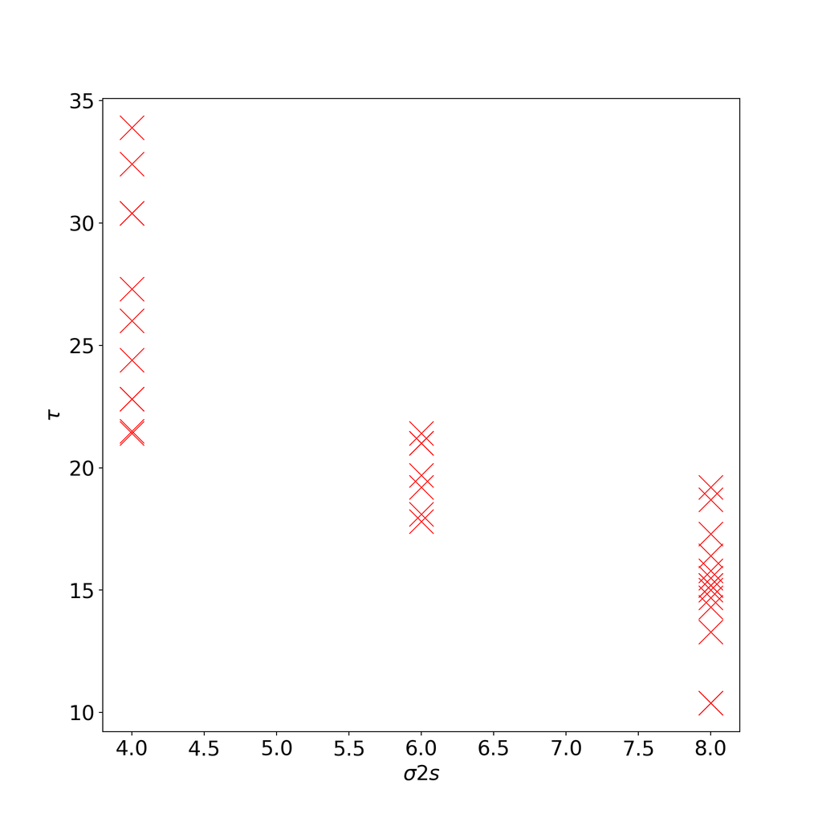

```python
f = sns.scatterplot(
    data=mtcars,
    x = 'cyl',
    y = 'mpg',
    color = 'red',
    s = 450,
    marker = 'x'
)
f.set(xlabel='$\sigma2s$', ylabel='$\\tau$');
plt.show()
```

#### Plot 2

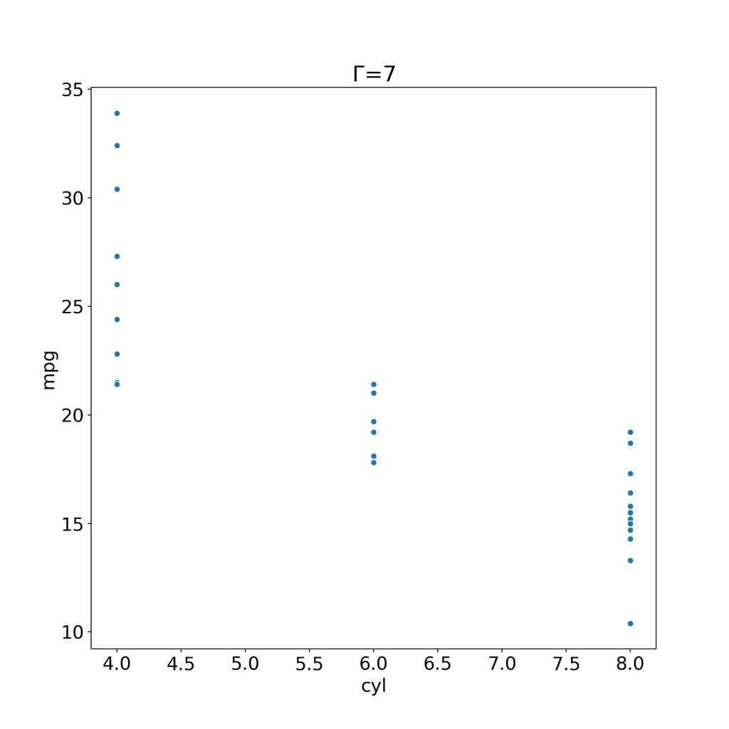

```python
y = 7
title = '$\Gamma$' + '=' + str(y)
f = sns.scatterplot(
    data=mtcars,
    x = 'cyl',
    y = 'mpg'
)
f.set(title = title)
plt.show()
```

#### Plot 3

Note that I moved the coords of the text box so that it would show up.

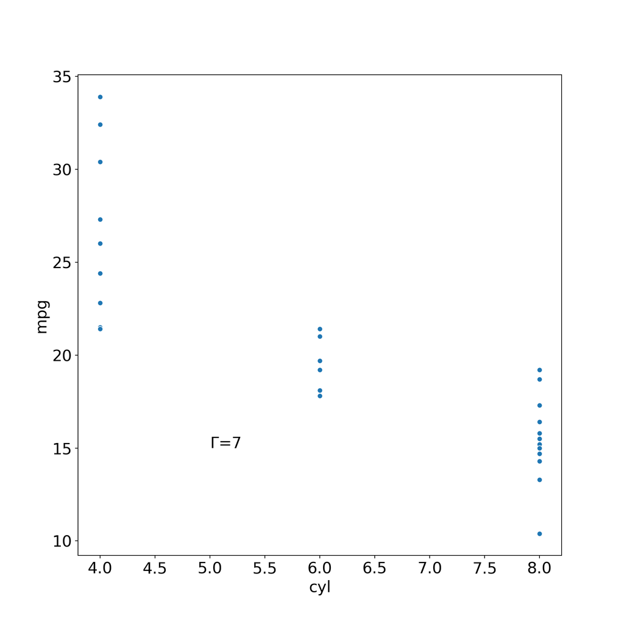

```python
y = 7
textstr = '$\Gamma$' + '=' + str(y)
f = sns.scatterplot(
    data=mtcars,
    x = 'cyl',
    y = 'mpg'
)
f.text(5, 15,textstr)
plt.show()
```

#### Multi-panel figures

Plot two plots side by side. (It is fine to plot the same plot next to itself.)

Do it again, but as a 2x2 matrix of 4 plots.

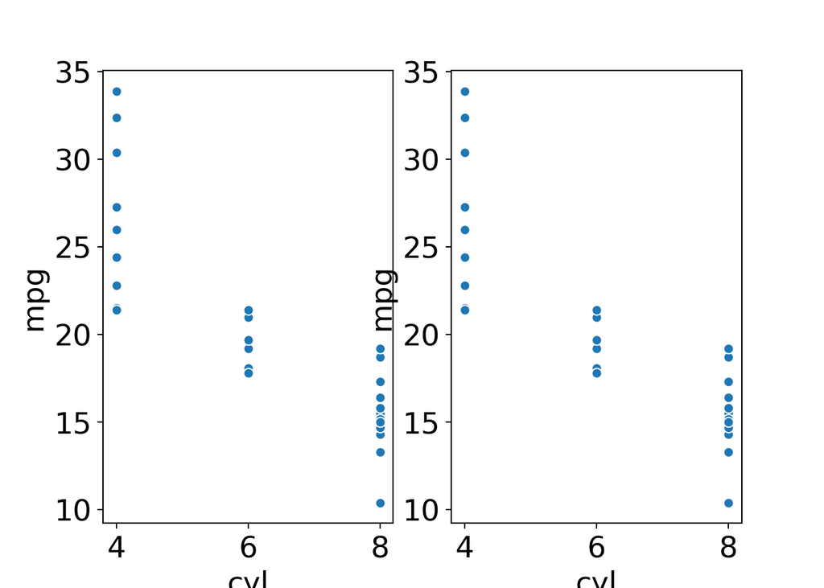

```python
fig, axs = plt.subplots(ncols=2)
sns.scatterplot(data=mtcars, x = 'cyl', y = 'mpg', ax=axs[0])
sns.scatterplot(data=mtcars, x = 'cyl', y = 'mpg', ax=axs[1])
plt.show()
```

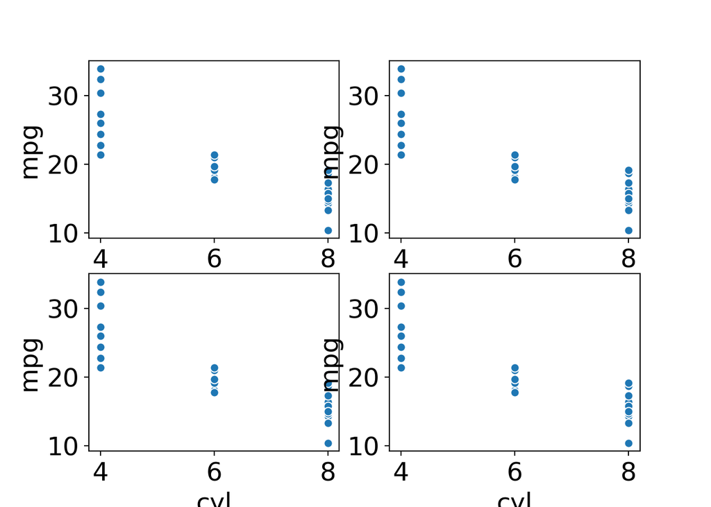

```python
fig, axs = plt.subplots(ncols=2, nrows=2)
sns.scatterplot(data=mtcars, x = 'cyl', y = 'mpg', ax=axs[0][0])
sns.scatterplot(data=mtcars, x = 'cyl', y = 'mpg', ax=axs[1][0])
sns.scatterplot(data=mtcars, x = 'cyl', y = 'mpg', ax=axs[0][1])
sns.scatterplot(data=mtcars, x = 'cyl', y = 'mpg', ax=axs[1][1])
plt.show()
```